# Practical Machine Learning Assignment Write-up

Ed Wong

1/3/2022

## Background

Using devices such as Jawbone Up, Nike FuelBand, and Fitbit it is now possible to collect a large amount of data about personal activity relatively inexpensively. These type of devices are part of the quantified self movement – a group of enthusiasts who take measurements about themselves regularly to improve their health, to find patterns in their behavior, or because they are tech geeks. One thing that people regularly do is quantify how much of a particular activity they do, but they rarely quantify how well they do it. In this project, your goal will be to use data from accelerometers on the belt, forearm, arm, and dumbell of 6 participants. They were asked to perform barbell lifts correctly and incorrectly in 5 different ways. More information is available from the website here: http://groupware.les.inf.puc-rio.br/har (see the section on the Weight Lifting Exercise Dataset).

## Data

### Training data

https://d396qusza40orc.cloudfront.net/predmachlearn/pml-training.csv

### Test data

https://d396qusza40orc.cloudfront.net/predmachlearn/pml-testing.csv

### Source

PUC-Rio http://groupware.les.inf.puc-rio.br/har

## Objective

The goal of your project is to predict the manner in which they did the exercise. This is the “classe” variable in the training set. You may use any of the other variables to predict with. You should create a report describing how you built your model, how you used cross validation, what you think the expected out of sample error is, and why you made the choices you did. You will also use your prediction model to predict 20 different test cases.

## Approach

We will first review the data for applicability, and clean-up / trim-down will be performed. Then the data will be partitioned into a training set and a testing set. A number of different models will be trained and run against the testing set. The model with the lowest error rate will be used for the final production of prediction results.

## Required libraries

First we load the libraries needed for this exercise.

```r
library(caret)
library(rpart)
```

Before we begin, we’ll set the random seed so the results are reproducible.

```r
set.seed(9527)
```

## Loading and cleaning up the data

First we load the raw training set and testing set data files from the URLs

```r
raw_train_data <- read.csv(url("https://d396qusza40orc.cloudfront.net/predmachlearn/pml-training.csv"))
raw_test_data <- read.csv(url("https://d396qusza40orc.cloudfront.net/predmachlearn/pml-testing.csv"))
```

Let’s do a quick check

```r
dim(raw_train_data)
```

```
## [1] 19622   160
```

```r
dim(raw_test_data)
```

```
## [1]  20 160
```

We could review the raw data in R at this point to get a sense of what kind of data the files contain; however, we did that offline instead in a text editor.

Both the training set and the testing set contain the same variables, except that the last column of the *training* set contains the labels (or the “classe” variable)

```r
head(raw_train_data[,c(157:160)])
```

```
##   magnet_forearm_x magnet_forearm_y magnet_forearm_z classe
## 1              -17              654              476      A
## 2              -18              661              473      A
## 3              -18              658              469      A
## 4              -16              658              469      A
## 5              -17              655              473      A
## 6               -9              660              478      A
```

And the last column of the *testing* set contains a dummy problem ID

```r
head(raw_test_data[,c(157:160)])
```

```
##   magnet_forearm_x magnet_forearm_y magnet_forearm_z problem_id
## 1             -714              419              617          1
## 2             -237              791              873          2
## 3              -51              698              783          3
## 4             -233              783              521          4
## 5              375             -787               91          5
## 6             -300              800              884          6
```

The first 7 columns are related to the participants of the study and timestamps for data collection.

```r
head(raw_train_data[,c(1:7)])
```

```
##   X user_name raw_timestamp_part_1 raw_timestamp_part_2   cvtd_timestamp
## 1 1  carlitos           1323084231               788290 05/12/2011 11:23
## 2 2  carlitos           1323084231               808298 05/12/2011 11:23
## 3 3  carlitos           1323084231               820366 05/12/2011 11:23
## 4 4  carlitos           1323084232               120339 05/12/2011 11:23
## 5 5  carlitos           1323084232               196328 05/12/2011 11:23
## 6 6  carlitos           1323084232               304277 05/12/2011 11:23
##   new_window num_window
## 1         no         11
## 2         no         11
## 3         no         11
## 4         no         12
## 5         no         12
## 6         no         12
```

```r
head(raw_test_data[,c(1:7)])
```

```
##   X user_name raw_timestamp_part_1 raw_timestamp_part_2   cvtd_timestamp
## 1 1     pedro           1323095002               868349 05/12/2011 14:23
## 2 2    jeremy           1322673067               778725 30/11/2011 17:11
## 3 3    jeremy           1322673075               342967 30/11/2011 17:11
## 4 4    adelmo           1322832789               560311 02/12/2011 13:33
## 5 5    eurico           1322489635               814776 28/11/2011 14:13
## 6 6    jeremy           1322673149               510661 30/11/2011 17:12
##   new_window num_window
## 1         no         74
## 2         no        431
## 3         no        439
## 4         no        194
## 5         no        235
## 6         no        504
```

Those are not needed and will be removed. The working sets will be called *tmp_train_data* and *tmp_test_data*

```r
tmp_train_data <- raw_train_data[,-c(1:7)]
tmp_test_data <- raw_test_data[,-c(1:7)]
dim(tmp_train_data)
```

```
## [1] 19622   153
```

```r
dim(tmp_test_data)
```

```
## [1]  20 153
```

Next we do a Near-Zero-Variance check for columns that we do not want to include when we train our models

```r
nzv_cols <- nearZeroVar(tmp_train_data, saveMetrics = TRUE)
```

Looks like we do have a number of near-zero-variance columns. Let’s remove them from both *tmp_train_data* and *tmp_test_data*.

```r
head(nzv_cols)
```

```
##                       freqRatio percentUnique zeroVar   nzv
## roll_belt              1.101904     6.7781062   FALSE FALSE
## pitch_belt             1.036082     9.3772296   FALSE FALSE
## yaw_belt               1.058480     9.9734991   FALSE FALSE
## total_accel_belt       1.063160     0.1477933   FALSE FALSE
## kurtosis_roll_belt  1921.600000     2.0232392   FALSE  TRUE
## kurtosis_picth_belt  600.500000     1.6155336   FALSE  TRUE
```

```r
tmp_train_data <- tmp_train_data[, nzv_cols$nzv==FALSE]
dim(tmp_train_data)
```

```
## [1] 19622    94
```

```r
tmp_test_data <- tmp_test_data[, nzv_cols$nzv==FALSE]
dim(tmp_test_data)
```

```
## [1] 20 94
```

The files also contained a lot of N/A values. We will remove columns that contain N/A values as well.

```r
na_cols <- apply(tmp_train_data, 2, function(x){any(is.na(x))})
na_cols
```

```
##                roll_belt               pitch_belt                 yaw_belt
##                    FALSE                    FALSE                    FALSE
##         total_accel_belt            max_roll_belt           max_picth_belt
##                    FALSE                     TRUE                     TRUE
##            min_roll_belt           min_pitch_belt      amplitude_roll_belt
##                     TRUE                     TRUE                     TRUE
##     amplitude_pitch_belt     var_total_accel_belt            avg_roll_belt
##                     TRUE                     TRUE                     TRUE
##         stddev_roll_belt            var_roll_belt           avg_pitch_belt
##                     TRUE                     TRUE                     TRUE
##        stddev_pitch_belt           var_pitch_belt             avg_yaw_belt
##                     TRUE                     TRUE                     TRUE
##          stddev_yaw_belt             var_yaw_belt             gyros_belt_x
##                     TRUE                     TRUE                    FALSE
##             gyros_belt_y             gyros_belt_z             accel_belt_x
##                    FALSE                    FALSE                    FALSE
##             accel_belt_y             accel_belt_z            magnet_belt_x
##                    FALSE                    FALSE                    FALSE
##            magnet_belt_y            magnet_belt_z                 roll_arm
##                    FALSE                    FALSE                    FALSE
##                pitch_arm                  yaw_arm          total_accel_arm
##                    FALSE                    FALSE                    FALSE
##            var_accel_arm              gyros_arm_x              gyros_arm_y
##                     TRUE                    FALSE                    FALSE
##              gyros_arm_z              accel_arm_x              accel_arm_y
##                    FALSE                    FALSE                    FALSE
##              accel_arm_z             magnet_arm_x             magnet_arm_y
##                    FALSE                    FALSE                    FALSE
##             magnet_arm_z            max_picth_arm              max_yaw_arm
##                    FALSE                     TRUE                     TRUE
##              min_yaw_arm        amplitude_yaw_arm            roll_dumbbell
##                     TRUE                     TRUE                    FALSE
##           pitch_dumbbell             yaw_dumbbell        max_roll_dumbbell
##                    FALSE                    FALSE                     TRUE
##       max_picth_dumbbell        min_roll_dumbbell       min_pitch_dumbbell
##                     TRUE                     TRUE                     TRUE
##  amplitude_roll_dumbbell amplitude_pitch_dumbbell     total_accel_dumbbell
##                     TRUE                     TRUE                    FALSE
##       var_accel_dumbbell        avg_roll_dumbbell     stddev_roll_dumbbell
##                     TRUE                     TRUE                     TRUE
```

[output cut: 9 more lines]

```
##                    FALSE                    FALSE                    FALSE
##        magnet_dumbbell_z             roll_forearm            pitch_forearm
##                    FALSE                    FALSE                    FALSE
##              yaw_forearm        max_picth_forearm        min_pitch_forearm
##                    FALSE                     TRUE                     TRUE
##  amplitude_pitch_forearm      total_accel_forearm        var_accel_forearm
##                     TRUE                    FALSE                     TRUE
##          gyros_forearm_x          gyros_forearm_y          gyros_forearm_z
##                    FALSE                    FALSE                    FALSE
##          accel_forearm_x          accel_forearm_y          accel_forearm_z
##                    FALSE                    FALSE                    FALSE
##         magnet_forearm_x         magnet_forearm_y         magnet_forearm_z
##                    FALSE                    FALSE                    FALSE
##                   classe
##                    FALSE
```

```r
train_data <- tmp_train_data[, !na_cols]
dim(train_data)
```

```
## [1] 19622    53
```

```r
test_data <- tmp_test_data[, !na_cols]
dim(test_data)
```

```
## [1] 20 53
```

We end up with 53 columns which will be much less computationally intensive to train compared with the original 160.

## Partitioning the training set

To build our models we’ll use roughly two thirds of the data for training and the rest for testing. For simplicity, we’ll just name the partitions *trn* and *tst*.

```r
train_rows = createDataPartition(y=train_data$classe, p=0.66, list=FALSE)
trn <- train_data[train_rows,]
dim(trn)
```

```
## [1] 12953    53
```

```r
tst <- train_data[-train_rows,]
dim(tst)
```

```
## [1] 6669   53
```

## Creating the prediction models

### Random Forest

We will train and create a model using the Random Forest algorithm (this step takes a while to complete).

```r
mod_rf <- randomForest::randomForest(as.factor(classe)~., data=trn)
mod_rf
```

```
##
## Call:
##  randomForest(formula = as.factor(classe) ~ ., data = trn)
##                Type of random forest: classification
##                      Number of trees: 500
## No. of variables tried at each split: 7
##
##         OOB estimate of  error rate: 0.56%
## Confusion matrix:
##      A    B    C    D    E class.error
## A 3679    4    0    0    0 0.001086071
## B   11 2492    4    0    0 0.005983247
## C    0   14 2239    6    0 0.008853475
## D    0    0   21 2101    1 0.010362694
## E    0    0    2    9 2370 0.004619908
```

Then we validate the model by performing prediction on the test set.

```r
predict_rf <- predict(mod_rf, tst, type="class")
```

Using the Confusion Matrix function, we check the model’s accuracy.

```r
cm_rf <- confusionMatrix(predict_rf, as.factor(tst$classe))
cm_rf
```

```
## Confusion Matrix and Statistics
##
##           Reference
## Prediction    A    B    C    D    E
##          A 1895    6    0    0    0
##          B    1 1281    4    0    0
##          C    0    3 1157   20    1
##          D    0    0    2 1072    1
##          E    1    0    0    1 1224
##
## Overall Statistics
##
##                Accuracy : 0.994
##                  95% CI : (0.9918, 0.9957)
##     No Information Rate : 0.2845
##     P-Value [Acc > NIR] : < 2.2e-16
##
##                   Kappa : 0.9924
##
##  Mcnemar's Test P-Value : NA
##
## Statistics by Class:
##
##                      Class: A Class: B Class: C Class: D Class: E
## Sensitivity            0.9989   0.9930   0.9948   0.9808   0.9984
## Specificity            0.9987   0.9991   0.9956   0.9995   0.9996
## Pos Pred Value         0.9968   0.9961   0.9797   0.9972   0.9984
## Neg Pred Value         0.9996   0.9983   0.9989   0.9962   0.9996
## Prevalence             0.2845   0.1934   0.1744   0.1639   0.1838
## Detection Rate         0.2842   0.1921   0.1735   0.1607   0.1835
## Detection Prevalence   0.2851   0.1928   0.1771   0.1612   0.1838
## Balanced Accuracy      0.9988   0.9960   0.9952   0.9901   0.9990
```

The accuracy is over 99% which is already very acceptable for the type of prediction being performed for this exercise. Let’s plot the model in a graph.

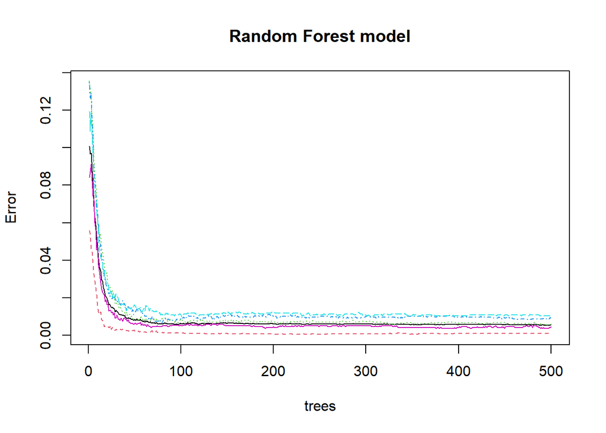

```r
plot(mod_rf, main = "Random Forest model")
```

We can see the Random Forest algo used in this prediction model becomes very accurate starting from 100 trees.

### Decision Tree

We will train and create a model using the Decision Tree algorithm (this step takes a while to complete).

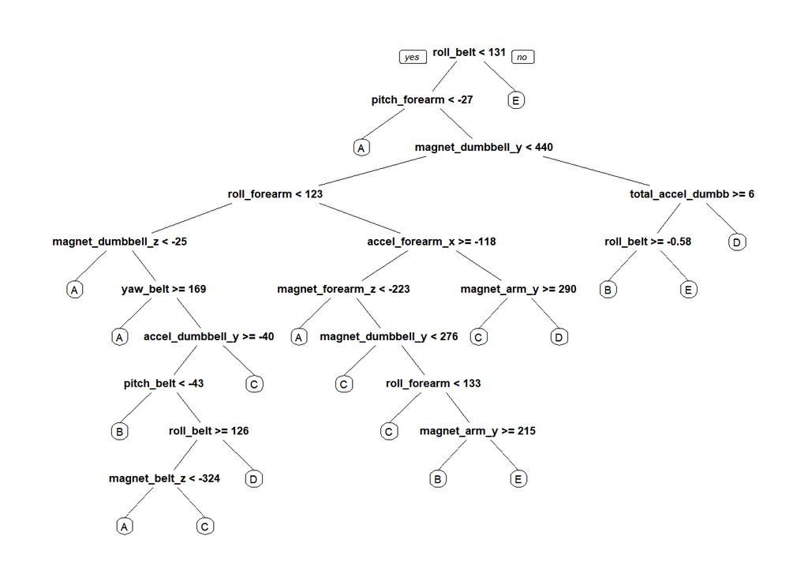

```r
mod_dt <- rpart(as.factor(classe)~., data=trn, method="class")
rpart.plot::prp(mod_dt)
```

Then we validate the model by performing prediction on the test set.

```r
predict_dt <- predict(mod_dt, tst, type="class")
```

Using the Confusion Matrix function, we check the model’s accuracy.

```r
cm_dt <- confusionMatrix(predict_dt, as.factor(tst$classe))
cm_dt
```

```
## Confusion Matrix and Statistics
##
##           Reference
## Prediction    A    B    C    D    E
##          A 1600  297   23   97   26
##          B   30  605   74   47   79
##          C   44  160  898   96  107
##          D  216  189  155  763  181
##          E    7   39   13   90  833
##
## Overall Statistics
##
##                Accuracy : 0.7046
##                  95% CI : (0.6935, 0.7155)
##     No Information Rate : 0.2845
##     P-Value [Acc > NIR] : < 2.2e-16
##
##                   Kappa : 0.6263
##
##  Mcnemar's Test P-Value : < 2.2e-16
##
## Statistics by Class:
##
##                      Class: A Class: B Class: C Class: D Class: E
## Sensitivity            0.8434  0.46899   0.7721   0.6981   0.6794
## Specificity            0.9072  0.95724   0.9261   0.8671   0.9726
## Pos Pred Value         0.7832  0.72455   0.6881   0.5073   0.8483
## Neg Pred Value         0.9358  0.88258   0.9506   0.9361   0.9309
## Prevalence             0.2845  0.19343   0.1744   0.1639   0.1838
## Detection Rate         0.2399  0.09072   0.1347   0.1144   0.1249
## Detection Prevalence   0.3063  0.12521   0.1957   0.2255   0.1472
## Balanced Accuracy      0.8753  0.71312   0.8491   0.7826   0.8260
```

The Decision Tree’s accuracy is around 70%.

## Final prediction

For the final prediction, we will be using the Random Forest model built earlier as it yields the smallest error rate. We’ll predict the provided testing set using that model.

```r
final_prediction <- predict(mod_rf, test_data, type="class")
final_prediction
```

```
##  1  2  3  4  5  6  7  8  9 10 11 12 13 14 15 16 17 18 19 20
##  B  A  B  A  A  E  D  B  A  A  B  C  B  A  E  E  A  B  B  B
## Levels: A B C D E
```

This concludes Practical Machine Learning assignment write-up.